# Vaccination Rate and Exemptions in Schools

Jackson Shands

12/14/2021

**Project description:** This data set contains information from schools about vaccination rates and exemptions (0-100%) along with enrollment and school type. The objective of this research is to investigate the relationship between school type (public or private), enrollment, and the number of medical exemptions granted to students. By developing a linear regression model, the aim is to predict the number of medical exemptions in a school given its type and enrollment size. A hypothesis test is also ran to detemerine the odds of students claiming a religious exemption to vaccination increase or decrease with public school status.

# Preprocessing:

- Loading file.
- Viewing dimensions.

# Feature Engineering:

## Create the following new variables:

- public_dummy = Indicator variable that is 1 for public school 0 for private.
- hi_enrollment = Indicator variable that is 1 when enrollment > mean enrollment.
- relig_exempt = Indicator that is 1 when religious > 0, and 0 otherwise.

## Viz for the raw data:

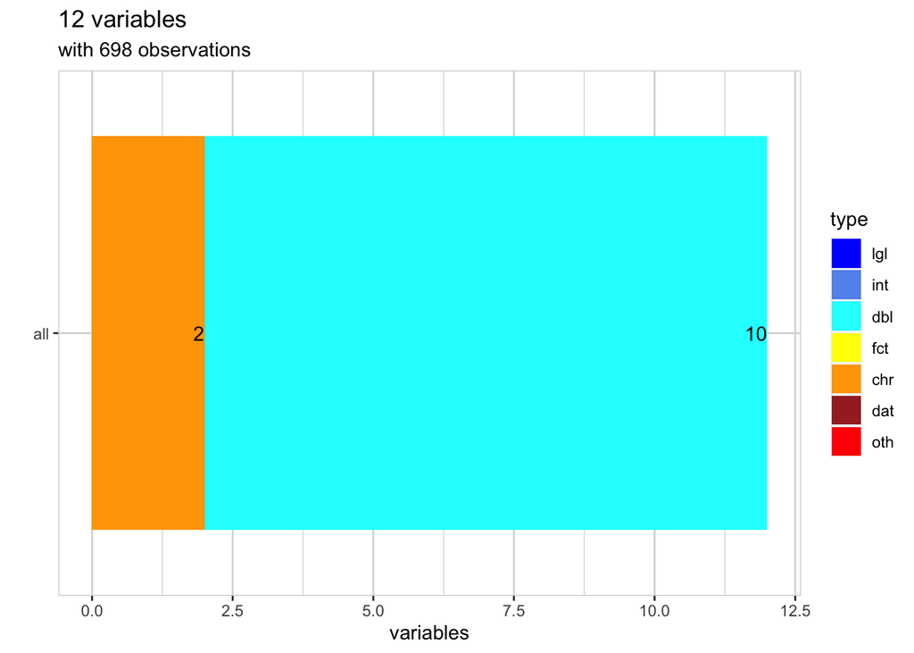

| variable | type | na | na_pct | unique | min | mean | max |
| --- | --- | --- | --- | --- | --- | --- | --- |
| name | chr | 0 | 0 | 667 | NA | NA | NA |
| pubpriv | chr | 0 | 0 | 2 | NA | NA | NA |
| enrollment | dbl | 0 | 0 | 166 | 10.00 | 79.05 | 199.00 |
| allvaccs | dbl | 0 | 0 | 419 | 16.67 | 89.04 | 100.00 |
| conditional | dbl | 0 | 0 | 337 | 0.00 | 6.73 | 81.82 |
| medical | dbl | 0 | 0 | 66 | 0.00 | 0.19 | 15.25 |
| religious | dbl | 0 | 0 | 261 | 0.00 | 4.04 | 75.00 |
| dptMiss | dbl | 0 | 0 | 400 | 0.00 | 8.71 | 83.33 |
| polMiss | dbl | 0 | 0 | 389 | 0.00 | 8.44 | 83.33 |
| mmrMiss | dbl | 0 | 0 | 403 | 0.00 | 8.89 | 83.33 |
| hepMiss | dbl | 0 | 0 | 344 | 0.00 | 6.44 | 83.33 |
| varMiss | dbl | 0 | 0 | 319 | 0.00 | 5.89 | 83.33 |

## Viz for the new variables that were created:

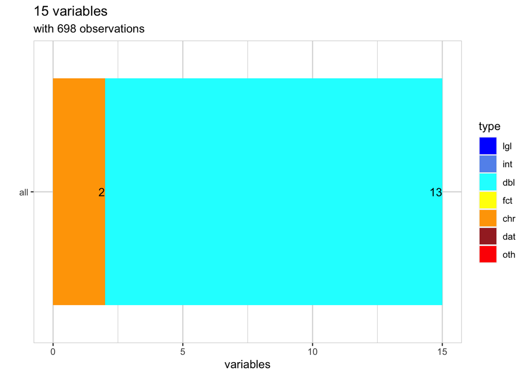

| variable | type | na | na_pct | unique | min | mean | max |
| --- | --- | --- | --- | --- | --- | --- | --- |
| name | chr | 0 | 0 | 667 | NA | NA | NA |
| pubpriv | chr | 0 | 0 | 2 | NA | NA | NA |
| enrollment | dbl | 0 | 0 | 166 | 10.00 | 79.05 | 199.00 |
| allvaccs | dbl | 0 | 0 | 419 | 16.67 | 89.04 | 100.00 |
| conditional | dbl | 0 | 0 | 337 | 0.00 | 6.73 | 81.82 |
| medical | dbl | 0 | 0 | 66 | 0.00 | 0.19 | 15.25 |
| religious | dbl | 0 | 0 | 261 | 0.00 | 4.04 | 75.00 |
| dptMiss | dbl | 0 | 0 | 400 | 0.00 | 8.71 | 83.33 |
| polMiss | dbl | 0 | 0 | 389 | 0.00 | 8.44 | 83.33 |
| mmrMiss | dbl | 0 | 0 | 403 | 0.00 | 8.89 | 83.33 |
| hepMiss | dbl | 0 | 0 | 344 | 0.00 | 6.44 | 83.33 |
| varMiss | dbl | 0 | 0 | 319 | 0.00 | 5.89 | 83.33 |
| public_dummy | dbl | 0 | 0 | 2 | 0.00 | 0.84 | 1.00 |
| relig_exempt | dbl | 0 | 0 | 2 | 0.00 | 0.57 | 1.00 |
| hi_enrollment | dbl | 0 | 0 | 2 | 0.00 | 0.48 | 1.00 |

##### Checking for duplicated character variable’s:

- 31 Total duplicate chr (school names) values found:

##### Count of all character values:

```
##   name pubpriv
## 1  698     698
```

##### Count of the unique chr values:

```
##   name pubpriv
## 1  667       2
```

##### Tallying of the duplicated school names:

- Group by school name

```
## # A tibble: 667 × 2
##    name                             n
##    <chr>                        <int>
##  1 FREMONT ELEMENTARY               5
##  2 WASHINGTON ELEMENTARY            4
##  3 BUENA VISTA ELEMENTARY           3
##  4 JEFFERSON ELEMENTARY             3
##  5 LINCOLN ELEMENTARY               3
##  6 LINDA VISTA ELEMENTARY           3
##  7 CHRISTA MCAULIFFE ELEMENTARY     2
##  8 DRY CREEK ELEMENTARY             2
##  9 GRANT ELEMENTARY                 2
## 10 GUADALUPE ELEMENTARY             2
## # … with 657 more rows
```

# Reporting solutions for each of the numerical variables in the data and the dummy variables.

### Descriptive Task(s):

| enrollment | allvaccs | conditional | medical | religious | dptMiss | polMiss | mmrMiss | hepMiss | varMiss | public_dummy | relig_exempt | hi_enrollment | n |
| --- | --- | --- | --- | --- | --- | --- | --- | --- | --- | --- | --- | --- | --- |
| 79.05014 | 89.03911 | 6.729765 | 0.1930648 | 4.038063 | 8.712155 | 8.436572 | 8.889257 | 6.441341 | 5.892554 | 0.8381089 | 0.5673352 | 0.4799427 | 698 |

##### Correlation with corrr / lava:

- Avoid multicollinearity
  - Correlation should be minimal between independent variable’s to avoid multicollinearity:

```
##
## Correlation method: 'pearson'
## Missing treated using: 'complete.obs'
```

| term | enrollment | allvaccs | conditional | medical | religious | dptMiss | polMiss | mmrMiss | hepMiss | varMiss | public_dummy | relig_exempt | hi_enrollment |
| --- | --- | --- | --- | --- | --- | --- | --- | --- | --- | --- | --- | --- | --- |
| enrollment | NA | 0.1563409 | -0.0138050 | 0.0422725 | -0.2164735 | -0.1555698 | -0.1867617 | -0.1900904 | -0.1790709 | -0.1895391 | 0.5059307 | 0.0527617 | 0.8098316 |
| allvaccs | 0.1563409 | NA | -0.7240576 | -0.0518164 | -0.6562677 | -0.9279058 | -0.9361993 | -0.9517362 | -0.8544299 | -0.8119527 | 0.0989267 | -0.2436425 | 0.1317892 |
| conditional | -0.0138050 | -0.7240576 | NA | -0.0275185 | -0.0413083 | 0.5173929 | 0.5137311 | 0.5744166 | 0.3423940 | 0.2566457 | 0.0140047 | -0.0271559 | -0.0099325 |
| medical | 0.0422725 | -0.0518164 | -0.0275185 | NA | 0.0124363 | 0.0541755 | 0.0612885 | 0.0650239 | 0.0686463 | 0.0865106 | -0.0375522 | 0.0075243 | 0.0179963 |
| religious | -0.2164735 | -0.6562677 | -0.0413083 | 0.0124363 | NA | 0.7780485 | 0.7934859 | 0.7491091 | 0.8619061 | 0.8925616 | -0.1559573 | 0.3839666 | -0.1827060 |
| dptMiss | -0.1555698 | -0.9279058 | 0.5173929 | 0.0541755 | 0.7780485 | NA | 0.9722043 | 0.9352875 | 0.9196177 | 0.9045976 | -0.0836555 | 0.2807739 | -0.1369509 |
| polMiss | -0.1867617 | -0.9361993 | 0.5137311 | 0.0612885 | 0.7934859 | 0.9722043 | NA | 0.9474576 | 0.9288600 | 0.9140991 | -0.1176593 | 0.2935525 | -0.1662134 |
| mmrMiss | -0.1900904 | -0.9517362 | 0.5744166 | 0.0650239 | 0.7491091 | 0.9352875 | 0.9474576 | NA | 0.8813901 | 0.8710623 | -0.1297393 | 0.2702454 | -0.1620379 |
| hepMiss | -0.1790709 | -0.8544299 | 0.3423940 | 0.0686463 | 0.8619061 | 0.9196177 | 0.9288600 | 0.8813901 | NA | 0.9765347 | -0.1248239 | 0.3289325 | -0.1595569 |
| varMiss | -0.1895391 | -0.8119527 | 0.2566457 | 0.0865106 | 0.8925616 | 0.9045976 | 0.9140991 | 0.8710623 | 0.9765347 | NA | -0.1338628 | 0.3238848 | -0.1643840 |
| public_dummy | 0.5059307 | 0.0989267 | 0.0140047 | -0.0375522 | -0.1559573 | -0.0836555 | -0.1176593 | -0.1297393 | -0.1248239 | -0.1338628 | NA | 0.0165554 | 0.4066417 |
| relig_exempt | 0.0527617 | -0.2436425 | -0.0271559 | 0.0075243 | 0.3839666 | 0.2807739 | 0.2935525 | 0.2702454 | 0.3289325 | 0.3238848 | 0.0165554 | NA | 0.0575483 |
| hi_enrollment | 0.8098316 | 0.1317892 | -0.0099325 | 0.0179963 | -0.1827060 | -0.1369509 | -0.1662134 | -0.1620379 | -0.1595569 | -0.1643840 | 0.4066417 | 0.0575483 | NA |

##### Interpretation:

- Starting with the graph on the right:
  - This graph suggest that there is a high positive correlation between public_dummy - enrollment - hi-enrollment.
- Now the graph on top:
  - Suggest that medical is weakly correlated with all variables.
- Lastly, the graph on the left represents:
  - The strongest correlation’s being grouped in the middle of this network
  - The weakest correlation in this bucket are religious and conditional.
    - Both Religious and conditional are still correlated with the variable’s in the middle.

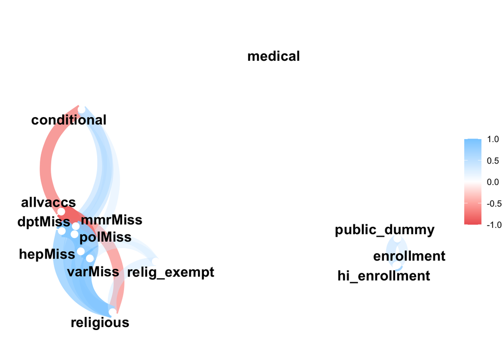

##### Cor with Basic:

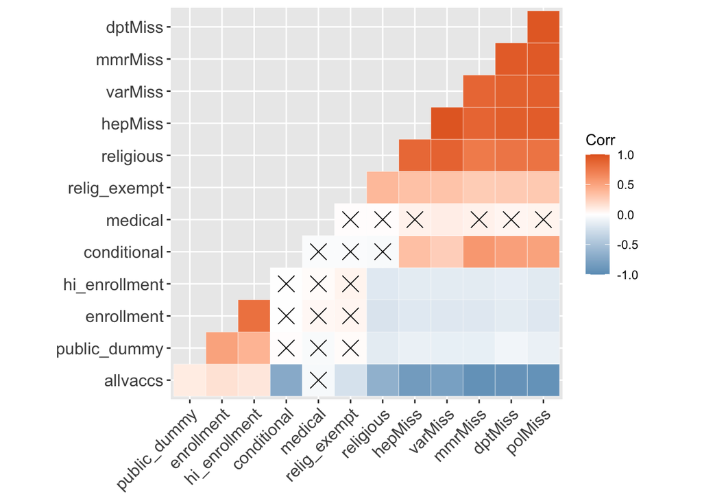

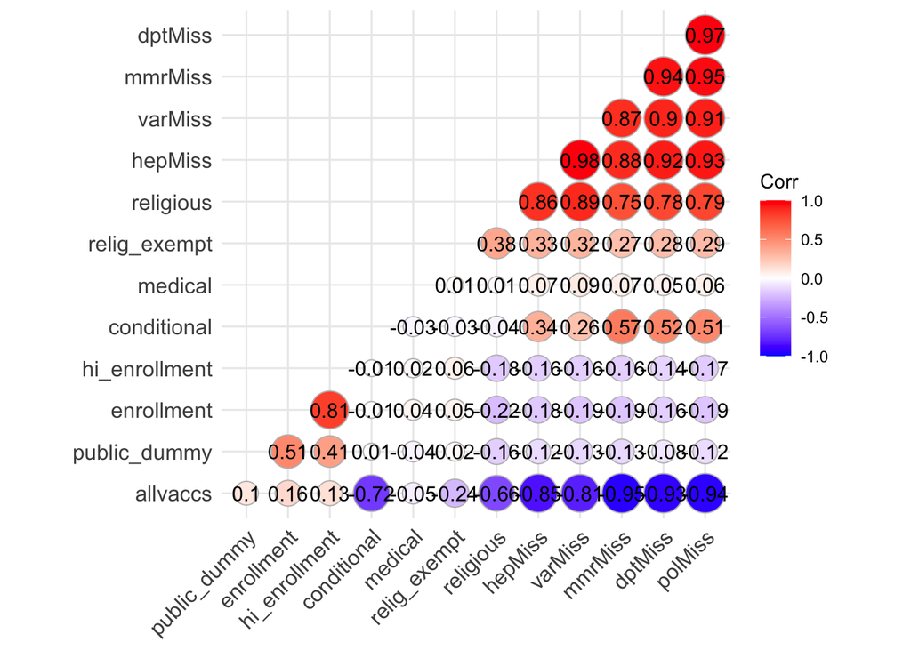

## Developing a linear regression model:

- Reseach Question: Can we develop a linear regression model to predict the number of medical exemptions in public and private schools based on school type and enrollment?
- Develop a linear regression model that predicts medical exemptions (“medical”) ~ from public / private school (“pubpriv”) and “enrollment”.

### Using Predictive Modeling Outputs to Enhance Decision-Making Solutions:

- Linear Regression: Evaluating the Relationship Between Dependent and Independent Variables.
- GOAL:
  - Minimize the error between the predicted and true values of the target variable.

### Hypothesis Test Set-up

- Ho:
  - There is no linear relationship and difference between the variables.
- Ha:
  - There is a linear relationship and difference between the variables.

### Spliting the data for all model’s:

- Splitting Method: (75/25):

### Building Linear Regression

- Tidy Modeling:

#### Steps:

- 1. Split data into training and test sets (done above)
- 2. Feature engineer
- 3. Build model ~ Fit model
- 4. Train model on the training data

```
## Linear Regression Model Specification (regression)
##
## Computational engine: lm
```

```
## # A tibble: 3 × 5
##   term          estimate std.error statistic p.value
##   <chr>            <dbl>     <dbl>     <dbl>   <dbl>
## 1 (Intercept)    0.272     0.107        2.55  0.0110
## 2 pubprivPUBLIC -0.231     0.130       -1.78  0.0759
## 3 enrollment     0.00155   0.00116      1.33  0.183
```

### Building a base Bayesian Model:

### Building a Tidy Bayes Regression Model

```
## parsnip model object
##
## Fit time:  2.2s
## stan_glm
##  family:       gaussian [identity]
##  formula:      medical ~ pubpriv + enrollment
##  observations: 522
##  predictors:   3
## ------
##               Median MAD_SD
## (Intercept)    0.3    0.1
## pubprivPUBLIC -0.2    0.1
## enrollment     0.0    0.0
##
## Auxiliary parameter(s):
##       Median MAD_SD
## sigma 0.9    0.0
##
## ------
## * For help interpreting the printed output see ?print.stanreg
## * For info on the priors used see ?prior_summary.stanreg
```

# Inerpretation of results from building Linear Regression models:

##### Below is a brief written interpretation of the results making sure to incorporate a discussion of hypothesis tests and p-values.

- In the supervised learning linear regression model built above are, the selected independent variable’s public or private school and the enrollment variable. These are set to observe an effect and predict the dependent variable medical exemptions.
- Below are the results:
  - Base Model and Tidy model
    - Same results.

##### Base Linear Model result:

```
##
## Call:
## lm(formula = medical ~ public_dummy + enrollment, data = df_training)
##
## Residuals:
##     Min      1Q  Median      3Q     Max
## -0.3758 -0.2325 -0.1741 -0.1266 15.1219
##
## Coefficients:
##               Estimate Std. Error t value Pr(>|t|)
## (Intercept)   0.272157   0.106614   2.553   0.0110 *
## public_dummy -0.231051   0.129920  -1.778   0.0759 .
## enrollment    0.001547   0.001161   1.333   0.1832
## ---
## Signif. codes:  0 '***' 0.001 '**' 0.01 '*' 0.05 '.' 0.1 ' ' 1
##
## Residual standard error: 0.927 on 519 degrees of freedom
## Multiple R-squared:  0.006469,   Adjusted R-squared:  0.002641
## F-statistic:  1.69 on 2 and 519 DF,  p-value: 0.1856
```

```
##    Min. 1st Qu.  Median    Mean 3rd Qu.    Max.
## -0.3758 -0.2325 -0.1741  0.0000 -0.1266 15.1219
```

##### Tidy Linear Model result

- Extract estimated coefficients, F-statistics, p-values, residual standard error (RMSE) and R2 value.
  - names()

```
##
## Call:
## stats::lm(formula = medical ~ pubpriv + enrollment, data = data)
##
## Residuals:
##     Min      1Q  Median      3Q     Max
## -0.3758 -0.2325 -0.1741 -0.1266 15.1219
##
## Coefficients:
##                Estimate Std. Error t value Pr(>|t|)
## (Intercept)    0.272157   0.106614   2.553   0.0110 *
## pubprivPUBLIC -0.231051   0.129920  -1.778   0.0759 .
## enrollment     0.001547   0.001161   1.333   0.1832
## ---
## Signif. codes:  0 '***' 0.001 '**' 0.01 '*' 0.05 '.' 0.1 ' ' 1
##
## Residual standard error: 0.927 on 519 degrees of freedom
## Multiple R-squared:  0.006469,   Adjusted R-squared:  0.002641
## F-statistic:  1.69 on 2 and 519 DF,  p-value: 0.1856
```

### Viz - Basic Linear Reg Model

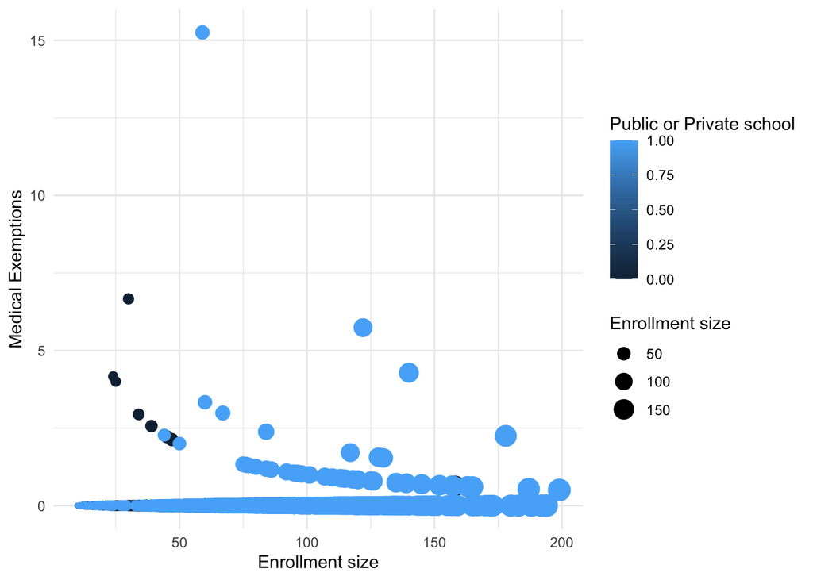

- There is at least one negative relationship for Medical exemptions and Enrollment size that is toward the higher enrollment size variable for schools.
  - There seems to be multiple layers within the data.
    - If this is graphed in 3-d space will show possible floors.

### Viz - Fitted model on training set

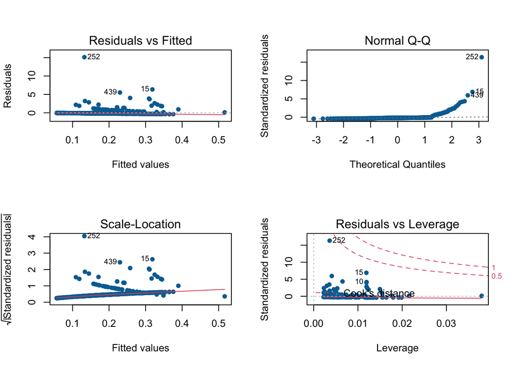

- Residuals vs Fitted
  - Linearity is violated.
- Scale Residuals vs Fitted
  - Curvature showing the residuals do not have a constant variance
    - This will cause challenges for inference.
- Normal Q-Q
  - Display’s non-normal data due to the curve.
    - Skew-right / Positively Skewed
      - The top end deviates from the linear line.
        - Represents the sample data having more extreme values than expected.
          - Resource:
- Residuals vs Leverage:
  - There is one significant point that fall’s along cook’s distance, and investigating the cause of this outlier will be important for determining whether to remove the observation or this is not the best model for the data.
  - Further investigation of the outliers will be good to look at.

```
## # A tibble: 3 × 5
##   term          estimate std.error statistic p.value
##   <chr>            <dbl>     <dbl>     <dbl>   <dbl>
## 1 (Intercept)    0.272     0.107        2.55  0.0110
## 2 pubprivPUBLIC -0.231     0.130       -1.78  0.0759
## 3 enrollment     0.00155   0.00116      1.33  0.183
```

```
## # A tibble: 1 × 12
##   r.squared adj.r.squared sigma statistic p.value    df logLik   AIC   BIC
##       <dbl>         <dbl> <dbl>     <dbl>   <dbl> <dbl>  <dbl> <dbl> <dbl>
## 1   0.00647       0.00264 0.927      1.69   0.186     2  -700. 1407. 1424.
## # … with 3 more variables: deviance <dbl>, df.residual <int>, nobs <int>
```

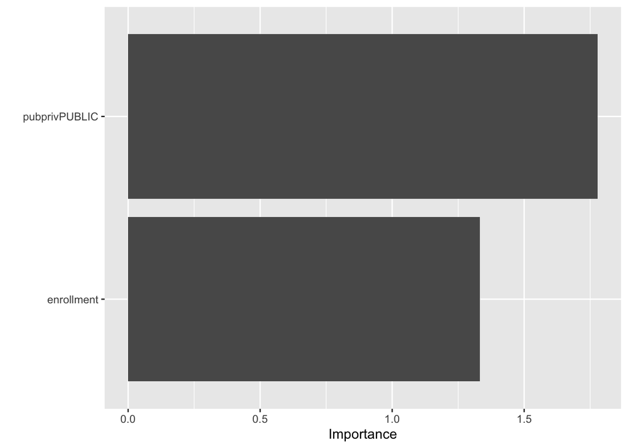

### Bayesian Inference for Linear regression:

### Bayes Reuslts

```
## Bayes factor analysis
## --------------
## [1] pubpriv + enrollment : 0.07108367 ±1.05%
##
## Against denominator:
##   Intercept only
## ---
## Bayes factor type: BFlinearModel, JZS
```

```
##
## Iterations = 1:10000
## Thinning interval = 1
## Number of chains = 1
## Sample size per chain = 10000
##
## 1. Empirical mean and standard deviation for each variable,
##    plus standard error of the mean:
##
##                            Mean        SD  Naive SE Time-series SE
## mu                     0.272381 5.873e-02 5.873e-04      5.737e-04
## pubpriv-PRIVATE        0.106835 6.316e-02 6.316e-04      6.316e-04
## pubpriv-PUBLIC        -0.106835 6.316e-02 6.316e-04      6.316e-04
## enrollment-enrollment  0.001428 1.131e-03 1.131e-05      1.131e-05
## sig2                   0.860422 5.416e-02 5.416e-04      5.416e-04
## g_pubpriv              1.170027 1.164e+01 1.164e-01      1.164e-01
## g_continuous           1.848199 1.349e+02 1.349e+00      1.349e+00
##
## 2. Quantiles for each variable:
##
##                             2.5%        25%       50%       75%    97.5%
## mu                     0.1557999  0.2331819  0.272415  0.311591 0.388252
## pubpriv-PRIVATE       -0.0165814  0.0650526  0.106364  0.149301 0.231206
## pubpriv-PUBLIC        -0.2312062 -0.1493013 -0.106364 -0.065053 0.016581
## enrollment-enrollment -0.0007654  0.0006665  0.001434  0.002191 0.003688
## sig2                   0.7610366  0.8233306  0.857999  0.894829 0.974100
## g_pubpriv              0.0379166  0.1019085  0.206371  0.498270 6.174491
## g_continuous           0.0178960  0.0474405  0.094964  0.231007 2.723843
```

#### Odds ratio:

- The odds ratio is not worth mentioning.
  - The odds ratio are 0.07108367 to 1 and a margin of error is plus or minus 1.05%, this is not odds in favor of the alternative hypothesis that public or private school and enrollment predict medical exemption.

#### Atempt at using the Tidy model - Bayesian:

- Challenges arose when:
  - Evaluating model and using bayes stats.
- Bayes Statistics resource new_package:

```
## # A tibble: 176 × 16
##     .pred name         pubpriv enrollment allvaccs conditional medical religious
##     <dbl> <chr>        <chr>        <dbl>    <dbl>       <dbl>   <dbl>     <dbl>
##  1 0.123  ASPIRE GATE… PUBLIC          53    100          0          0      0
##  2 0.338  SANTA FE CH… PRIVATE         42     76.2       11.9        0     11.9
##  3 0.177  RIVERDALE E… PUBLIC          88     97.7        2.27       0      0
##  4 0.117  LUGO ELEMEN… PUBLIC          49     79.6       20.4        0      0
##  5 0.0718 STONE CORRA… PUBLIC          20     95          5          0      0
##  6 0.134  FOOTHILL KN… PUBLIC          60     85         11.7        0      3.33
##  7 0.347  HEIGHTS CHR… PRIVATE         48     81.2       16.7        0      2.08
##  8 0.0563 SVEN LOKRAN… PUBLIC          10    100          0          0      0
##  9 0.304  ST. AGNES P… PRIVATE         20     90         10          0      0
## 10 0.179  ETHEL PHILL… PUBLIC          89     97.8        2.25       0      0
## # … with 166 more rows, and 8 more variables: dptMiss <dbl>, polMiss <dbl>,
## #   mmrMiss <dbl>, hepMiss <dbl>, varMiss <dbl>, public_dummy <dbl>,
## #   relig_exempt <dbl>, hi_enrollment <dbl>
```

# Run a logistic regression model:

- Run a logistic regression model using public_dummy and enrollment to predict relig_exempt (0 or 1) based on being in public or private school and enrollment size of a school.
- Reporting the results using public_dummy and enrollment to predict relig_exempt in solutions.

```
##
## Call:
## glm(formula = relig_exempt ~ enrollment + public_dummy, family = binomial(),
##     data = df_training)
##
## Deviance Residuals:
##     Min       1Q   Median       3Q      Max
## -1.4725  -1.2930   0.9886   1.0497   1.1823
##
## Coefficients:
##               Estimate Std. Error z value Pr(>|z|)
## (Intercept)  -0.042526   0.230622  -0.184    0.854
## enrollment    0.003106   0.002560   1.214    0.225
## public_dummy  0.111332   0.281807   0.395    0.693
##
## (Dispersion parameter for binomial family taken to be 1)
##
##     Null deviance: 712.54  on 521  degrees of freedom
## Residual deviance: 709.55  on 519  degrees of freedom
## AIC: 715.55
##
## Number of Fisher Scoring iterations: 4
```

```
## [1] 0.04727531
```

```
##  (Intercept)   enrollment public_dummy
##    0.9583655    1.0031110    1.1177665
```

```
##                  2.5 %   97.5 %
## (Intercept)  0.6092306 1.508864
## enrollment   0.9981159 1.008204
## public_dummy 0.6423183 1.942758
```

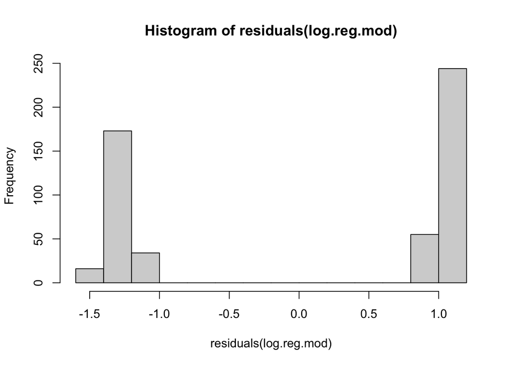

# A write up of the results from the logistic regression model, with an interpretation of the question:

- “how do the odds of students claiming a religious exemption to vaccination increase or decrease with public school status?”.
  - Incorporate a discussion of hypothesis tests , p-values and odds ratios.

### Hypothesis Test Set-up

- Ho: There is no linear relationship and difference between the variables.
- Ha: There is a linear relationship and difference between the variables.

### Hypothesis Test and P-values

- For both, enrollment size and public vs. private school variable’s the corresponding p-value on the F-stat on overall fit is large, meaning the regression is not fit as well as the associated z-scores.
  - enrollment:
    - z-value: 1.214
    - p = 0.225 == p>.05
  - public_dummy:
    - z-value: 0.395
    - p = 0.693 == p>.05
- Referencing the outcome above, the decision is to fail to reject the null hypothesis,
  - which is the log-odds of enrollment size and the log-odds of public vs. private school variable’s is equal to 0 in the population.

#### Odds: odd ratio for coefficients:

- The odds of 0.9583655:1 is the proportion for having a religious exemption by a person not enrolled in a school.
  - A person is about 4.2% for having a religious exemption to vaccination by a person not enrolled in a school.
- Every increase of one in the enrollment size of a school is associated with a 1.0031110 to 1 increase in the odds of enrollment
  - For each student enrolled at a school, there is a 0.31% increase in the likelihood of a religious exemption to vaccination
    - Just about a 1 to 1 for each coefficient. Can be significant based on scale.
- Every increase of one in public_dummy is associated with a 1.1177665 to 1 increase in the odds of relig_exempt.
  - A person is about 11% more likely to have a religious exemption to vaccination in a public school.

### By looking at p-value’s of the z statistic for both coeffients there is a strong likelihood that these observations occurring are due to chance.

- For the variable enrollment size there is about a 23% probability that an observed difference between the observed results and expected results is due to chance or sampling error.
- For the variable public pr private school There is a 69% probability that an observed difference between the observed results and expected results is due to chance or sampling error.

### Overall, the conclusion drawn from the hypothesis test does not align with the conclusions drawn from the odds ratio.

```
## # A tibble: 509 × 3
## # Groups:   name [499]
##    name                      relig_exempt     n
##    <chr>                            <dbl> <int>
##  1 FREMONT ELEMENTARY                   1     3
##  2 BUENA VISTA ELEMENTARY               1     2
##  3 DRY CREEK ELEMENTARY                 1     2
##  4 GRANT ELEMENTARY                     1     2
##  5 JEFFERSON ELEMENTARY                 0     2
##  6 KINGSLEY ELEMENTARY                  0     2
##  7 LAKEVIEW ELEMENTARY                  1     2
##  8 LINCOLN ELEMENTARY                   0     2
##  9 LUTHER BURBANK ELEMENTARY            1     2
## 10 PARK AVENUE ELEMENTARY               0     2
## # … with 499 more rows
```

```
## # A tibble: 522 × 15
## # Groups:   name [499]
##    name        pubpriv enrollment allvaccs conditional medical religious dptMiss
##    <chr>       <chr>        <dbl>    <dbl>       <dbl>   <dbl>     <dbl>   <dbl>
##  1 MONTEREY R… PUBLIC         199     96.0       0       0.503     3.52     4.02
##  2 SYLVAN PAR… PUBLIC         194     99.0       1.03    0         0        0
##  3 FAIRMONT E… PUBLIC         192     88.5       3.12    0         8.33     9.90
##  4 MILL STREE… PUBLIC         188    100         0       0         0        0
##  5 OLEANDER E… PUBLIC         187     98.9       0.535   0.535     0        1.07
##  6 DESERT ROS… PUBLIC         183     96.7       2.73    0         0.546    3.28
##  7 ART HAYCOX… PUBLIC         180     98.3       1.67    0         0        1.67
##  8 NATOMAS PA… PUBLIC         180     72.2      24.4     0         3.33    20.6
##  9 WOODBURY E… PUBLIC         178     80.9      16.9     2.25      0       14.0
## 10 FOSTER ELE… PUBLIC         173     93.1       6.94    0         0        5.78
## # … with 512 more rows, and 7 more variables: polMiss <dbl>, mmrMiss <dbl>,
## #   hepMiss <dbl>, varMiss <dbl>, public_dummy <dbl>, relig_exempt <dbl>,
## #   hi_enrollment <dbl>
```